# IMPORTING NECESSARY LIBRARIES

```python
import pandas as pd
import numpy as np
import squarify
import matplotlib.pyplot as plt
import seaborn as sns
```

# INTRODUCTION

The Ford GoBike dataset provides a comprehensive overview of bike-sharing activities within a specified timeframe. With a total of 16 columns and over 183,000 rows, this dataset encapsulates crucial information about bike trips, including duration, start and end times, station locations, user demographics, and bike share status. Analyzing this dataset can unveil valuable insights into urban mobility patterns, user behaviors, and operational dynamics, informing strategic decision-making for bike-sharing programs and urban transportation planning initiatives.

- The columns include the following

**duration_sec:** This column represents the duration of each bike trip in seconds. It indicates how long each trip lasted from start to finish.

**start_time:** This column denotes the start time of each bike trip. It provides information on when the trip commenced, including the date and time.

**end_time:** This column indicates the end time of each bike trip. It specifies when the trip concluded, including the date and time.

**start_station_id:** This column contains the unique identifier for the starting station of each bike trip. It helps identify the specific station where the bike trip originated.

**start_station_name:** This column provides the name or description of the starting station for each bike trip. It offers additional context about the location where the trip began.

**start_station_latitude:** This column denotes the latitude coordinates of the starting station. It specifies the geographic location of the station in terms of its north-south position.

**start_station_longitude:** This column represents the longitude coordinates of the starting station. It specifies the geographic location of the station in terms of its east-west position.

**end_station_id:** This column contains the unique identifier for the ending station of each bike trip. It helps identify the specific station where the bike trip concluded.

**end_station_name:** This column provides the name or description of the ending station for each bike trip. It offers additional context about the location where the trip ended.

**end_station_latitude:** This column denotes the latitude coordinates of the ending station. It specifies the geographic location of the station where the trip concluded in terms of its north-south position.

**end_station_longitude:** This column represents the longitude coordinates of the ending station. It specifies the geographic location of the station where the trip concluded in terms of its east-west position.

**bike_id:** This column contains the unique identifier for each bike used in the bike-sharing program. It helps track individual bikes and their usage over time.

**user_type:** This column indicates the type of user who took the bike trip, such as a subscriber or customer. It categorizes users based on their subscription status.

**member_birth_year:** This column represents the birth year of the bike trip user. It provides information about the age of the user, which can be derived from their birth year.

**member_gender:** This column denotes the gender of the bike trip user. It categorizes users based on their gender identity, such as male, female, or other.

**bike_share_for_all_trip:** This column indicates whether the bike trip was shared for all or part of the journey as part of a bike-sharing program. It provides information on the bike-sharing status of the trip.

```python
Bike = pd.read_csv(r"C:\Users\User pc\Desktop\FINALE PROJECT\archive\201902-fordgobike-tripdata.csv")
Bike
```

|  | duration_sec | start_time | end_time | start_station_id | start_station_name | start_station_latitude | start_station_longitude | end_station_id | end_station_name | end_station_latitude | end_station_longitude | bike_id | user_type | member_birth_year | member_gender | bike_share_for_all_trip |
| --- | --- | --- | --- | --- | --- | --- | --- | --- | --- | --- | --- | --- | --- | --- | --- | --- |
| 0 | 52185 | 2019-02-28 17:32:10.1450 | 2019-03-01 08:01:55.9750 | 21.0 | Montgomery St BART Station (Market St at 2nd St) | 37.789625 | -122.400811 | 13.0 | Commercial St at Montgomery St | 37.794231 | -122.402923 | 4902 | Customer | 1984.0 | Male | No |
| 1 | 42521 | 2019-02-28 18:53:21.7890 | 2019-03-01 06:42:03.0560 | 23.0 | The Embarcadero at Steuart St | 37.791464 | -122.391034 | 81.0 | Berry St at 4th St | 37.775880 | -122.393170 | 2535 | Customer | NaN | NaN | No |
| 2 | 61854 | 2019-02-28 12:13:13.2180 | 2019-03-01 05:24:08.1460 | 86.0 | Market St at Dolores St | 37.769305 | -122.426826 | 3.0 | Powell St BART Station (Market St at 4th St) | 37.786375 | -122.404904 | 5905 | Customer | 1972.0 | Male | No |
| 3 | 36490 | 2019-02-28 17:54:26.0100 | 2019-03-01 04:02:36.8420 | 375.0 | Grove St at Masonic Ave | 37.774836 | -122.446546 | 70.0 | Central Ave at Fell St | 37.773311 | -122.444293 | 6638 | Subscriber | 1989.0 | Other | No |
| 4 | 1585 | 2019-02-28 23:54:18.5490 | 2019-03-01 00:20:44.0740 | 7.0 | Frank H Ogawa Plaza | 37.804562 | -122.271738 | 222.0 | 10th Ave at E 15th St | 37.792714 | -122.248780 | 4898 | Subscriber | 1974.0 | Male | Yes |
| ... | ... | ... | ... | ... | ... | ... | ... | ... | ... | ... | ... | ... | ... | ... | ... | ... |
| 183407 | 480 | 2019-02-01 00:04:49.7240 | 2019-02-01 00:12:50.0340 | 27.0 | Beale St at Harrison St | 37.788059 | -122.391865 | 324.0 | Union Square (Powell St at Post St) | 37.788300 | -122.408531 | 4832 | Subscriber | 1996.0 | Male | No |
| 183408 | 313 | 2019-02-01 00:05:34.7440 | 2019-02-01 00:10:48.5020 | 21.0 | Montgomery St BART Station (Market St at 2nd St) | 37.789625 | -122.400811 | 66.0 | 3rd St at Townsend St | 37.778742 | -122.392741 | 4960 | Subscriber | 1984.0 | Male | No |
| 183409 | 141 | 2019-02-01 00:06:05.5490 | 2019-02-01 00:08:27.2200 | 278.0 | The Alameda at Bush St | 37.331932 | -121.904888 | 277.0 | Morrison Ave at Julian St | 37.333658 | -121.908586 | 3824 | Subscriber | 1990.0 | Male | Yes |
| 183410 | 139 | 2019-02-01 00:05:34.3600 | 2019-02-01 00:07:54.2870 | 220.0 | San Pablo Ave at MLK Jr Way | 37.811351 | -122.273422 | 216.0 | San Pablo Ave at 27th St | 37.817827 | -122.275698 | 5095 | Subscriber | 1988.0 | Male | No |
| 183411 | 271 | 2019-02-01 00:00:20.6360 | 2019-02-01 00:04:52.0580 | 24.0 | Spear St at Folsom St | 37.789677 | -122.390428 | 37.0 | 2nd St at Folsom St | 37.785000 | -122.395936 | 1057 | Subscriber | 1989.0 | Male | No |

183412 rows × 16 columns

```python
Bike.columns
```

```
Index(['duration_sec', 'start_time', 'end_time', 'start_station_id',
       'start_station_name', 'start_station_latitude',
       'start_station_longitude', 'end_station_id', 'end_station_name',
       'end_station_latitude', 'end_station_longitude', 'bike_id', 'user_type',
       'member_birth_year', 'member_gender', 'bike_share_for_all_trip'],
      dtype='object')
```

```python
Bike.info()
```

```
<class 'pandas.core.frame.DataFrame'>
RangeIndex: 183412 entries, 0 to 183411
Data columns (total 16 columns):
 #   Column                   Non-Null Count   Dtype
---  ------                   --------------   -----
 0   duration_sec             183412 non-null  int64
 1   start_time               183412 non-null  object
 2   end_time                 183412 non-null  object
 3   start_station_id         183215 non-null  float64
 4   start_station_name       183215 non-null  object
 5   start_station_latitude   183412 non-null  float64
 6   start_station_longitude  183412 non-null  float64
 7   end_station_id           183215 non-null  float64
 8   end_station_name         183215 non-null  object
 9   end_station_latitude     183412 non-null  float64
 10  end_station_longitude    183412 non-null  float64
 11  bike_id                  183412 non-null  int64
 12  user_type                183412 non-null  object
 13  member_birth_year        175147 non-null  float64
 14  member_gender            175147 non-null  object
 15  bike_share_for_all_trip  183412 non-null  object
dtypes: float64(7), int64(2), object(7)
memory usage: 22.4+ MB
```

```python
Bike.shape
```

```
(183412, 16)
```

# CLEANING THE DATASET

```python
# Check for missing values
Bike.isnull().sum()
```

```
duration_sec                  0
start_time                    0
end_time                      0
start_station_id            197
start_station_name          197
start_station_latitude        0
start_station_longitude       0
end_station_id              197
end_station_name            197
end_station_latitude          0
end_station_longitude         0
bike_id                       0
user_type                     0
member_birth_year          8265
member_gender              8265
bike_share_for_all_trip       0
dtype: int64
```

```python
# Drop rows with missing values (if applicable)
Bike_cleaned = Bike.dropna()
```

```python
# Convert start_time and end_time to datetime objects
Bike_cleaned.loc[:, 'start_time'] = pd.to_datetime(Bike_cleaned['start_time'])
Bike_cleaned.loc[:, 'end_time'] = pd.to_datetime(Bike_cleaned['end_time'])
```

```python
# Convert member_birth_year to integer (if ne
Bike_cleaned.loc[:, 'member_birth_year'] = Bike_cleaned['member_birth_year'].astype(int)
```

```python
# Drop duplicates (if applicable)
Bike_cleaned = Bike_cleaned.drop_duplicates()
```

```python
# Check the cleaned dataset
Bike_cleaned.info()
```

```
<class 'pandas.core.frame.DataFrame'>
Index: 174952 entries, 0 to 183411
Data columns (total 16 columns):
 #   Column                   Non-Null Count   Dtype
---  ------                   --------------   -----
 0   duration_sec             174952 non-null  int64
 1   start_time               174952 non-null  object
 2   end_time                 174952 non-null  object
 3   start_station_id         174952 non-null  float64
 4   start_station_name       174952 non-null  object
 5   start_station_latitude   174952 non-null  float64
 6   start_station_longitude  174952 non-null  float64
 7   end_station_id           174952 non-null  float64
 8   end_station_name         174952 non-null  object
 9   end_station_latitude     174952 non-null  float64
 10  end_station_longitude    174952 non-null  float64
 11  bike_id                  174952 non-null  int64
 12  user_type                174952 non-null  object
 13  member_birth_year        174952 non-null  float64
 14  member_gender            174952 non-null  object
 15  bike_share_for_all_trip  174952 non-null  object
dtypes: float64(7), int64(2), object(7)
memory usage: 22.7+ MB
```

# EXPLORATION

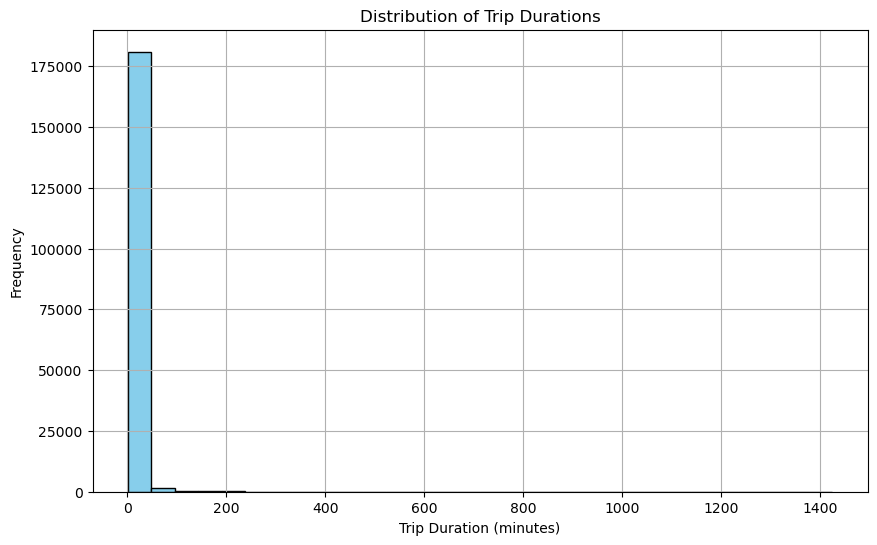

```python
# Histogram of trip durations
plt.figure(figsize=(10, 6))
plt.hist(Bike['duration_sec'] / 60, bins=30, color='skyblue', edgecolor='black')
plt.title('Distribution of Trip Durations')
plt.xlabel('Trip Duration (minutes)')
plt.ylabel('Frequency')
plt.grid(True)
plt.show()
```

```python
# Group the data by user type and calculate aggregate statistics
usage_by_user_type = Bike.groupby('user_type').agg(
    total_trips=('user_type', 'count'),
    average_duration=('duration_sec', 'mean')
)
```

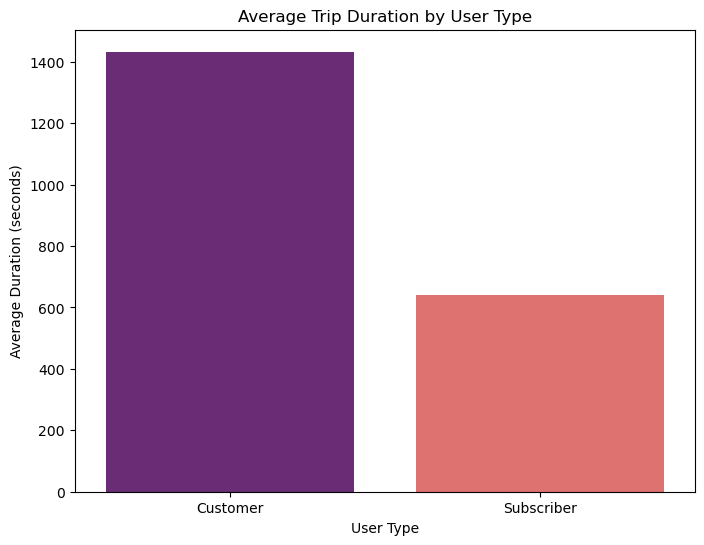

```python
# Plot the average trip duration by user type
plt.figure(figsize=(8, 6))
sns.barplot(x=usage_by_user_type.index, y='average_duration', data=usage_by_user_type, palette='magma')
plt.title('Average Trip Duration by User Type')
plt.xlabel('User Type')
plt.ylabel('Average Duration (seconds)')
plt.show()
```

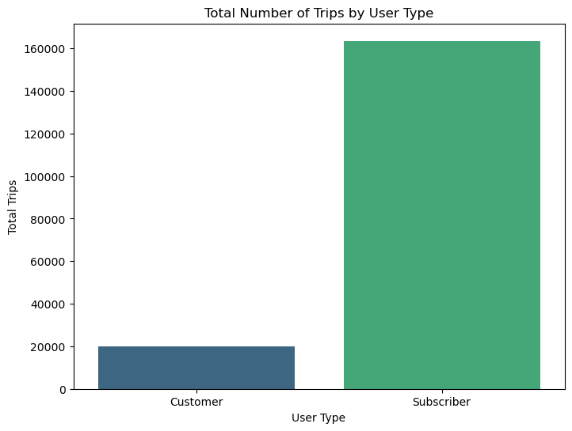

```python
# Plot the total number of trips by user type
plt.figure(figsize=(8, 6))
sns.barplot(x=usage_by_user_type.index, y='total_trips', data=usage_by_user_type, palette='viridis')
plt.title('Total Number of Trips by User Type')
plt.xlabel('User Type')
plt.ylabel('Total Trips')
plt.show()
```

```python
# Group the data by gender and calculate aggregate statistics
usage_by_gender = Bike.groupby('member_gender').agg(
    total_trips=('member_gender', 'count'),
    average_duration=('duration_sec', 'mean')
)
```

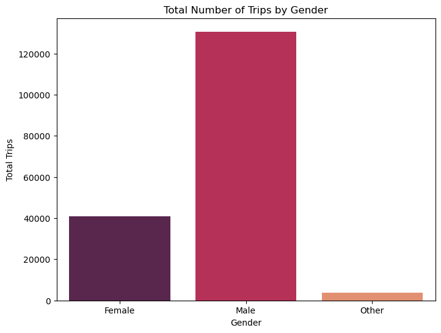

```python
# Plot the total number of trips by gender
plt.figure(figsize=(8, 6))
sns.barplot(x=usage_by_gender.index, y='total_trips', data=usage_by_gender, palette='rocket')
plt.title('Total Number of Trips by Gender')
plt.xlabel('Gender')
plt.ylabel('Total Trips')
plt.show()
```

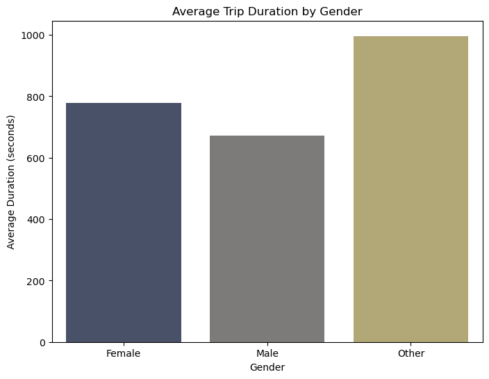

```python
# Plot the average trip duration by gender
plt.figure(figsize=(8, 6))
sns.barplot(x=usage_by_gender.index, y='average_duration', data=usage_by_gender, palette='cividis')
plt.title('Average Trip Duration by Gender')
plt.xlabel('Gender')
plt.ylabel('Average Duration (seconds)')
plt.show()
```

```python
# Extract the hour from the start_time column
Bike['start_hour'] = pd.to_datetime(Bike['start_time']).dt.hour
```

```python
# Group the data by start hour and calculate the total number of trips
usage_by_hour = Bike.groupby('start_hour').size()
```

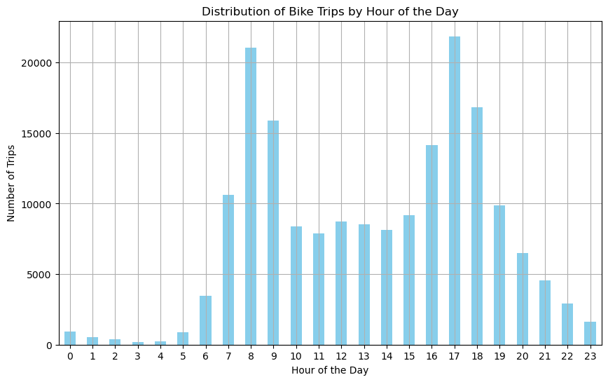

```python
# Plot the distribution of bike trips over different hours of the day
plt.figure(figsize=(10, 6))
usage_by_hour.plot(kind='bar', color='skyblue')
plt.title('Distribution of Bike Trips by Hour of the Day')
plt.xlabel('Hour of the Day')
plt.ylabel('Number of Trips')
plt.xticks(rotation=0)
plt.grid(True)
plt.show()
```

```python
# Group the data by start station and calculate the total number of trips for each start station
start_station_usage = Bike.groupby('start_station_name').size().sort_values(ascending=False)
```

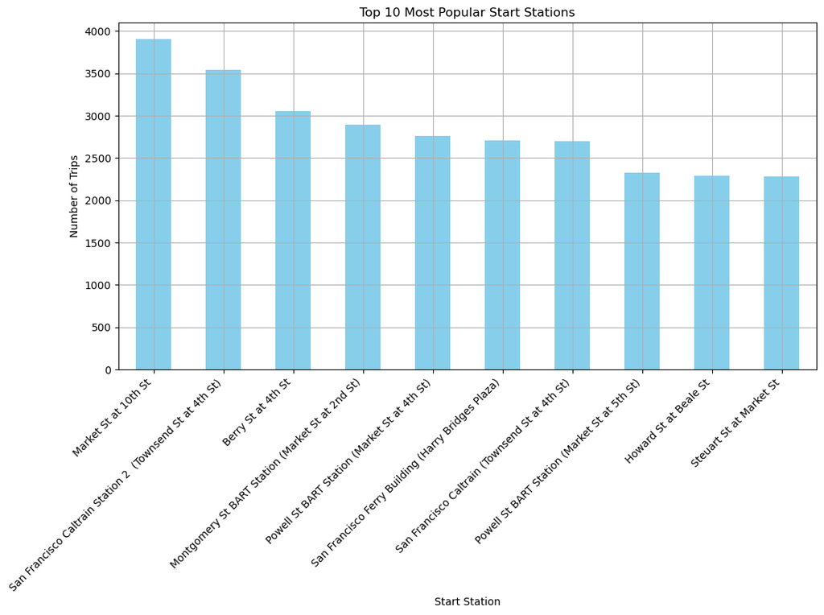

```python
# Plot the top 10 most popular start stations
plt.figure(figsize=(12, 6))
start_station_usage.head(10).plot(kind='bar', color='skyblue')
plt.title('Top 10 Most Popular Start Stations')
plt.xlabel('Start Station')
plt.ylabel('Number of Trips')
plt.xticks(rotation=45, ha='right')
plt.grid(True)
plt.show()
```

```python
# Group the data by end station and calculate the total number of trips for each end station
end_station_usage = Bike.groupby('end_station_name').size().sort_values(ascending=False)
```

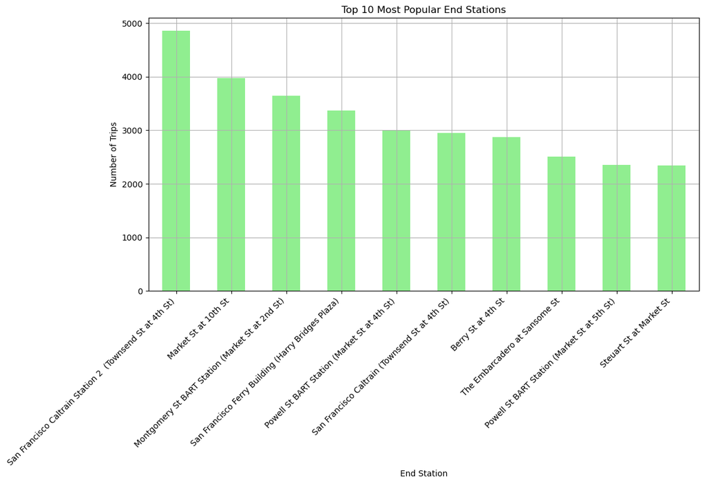

```python
# Plot the top 10 most popular end stations
plt.figure(figsize=(12, 6))
end_station_usage.head(10).plot(kind='bar', color='lightgreen')
plt.title('Top 10 Most Popular End Stations')
plt.xlabel('End Station')
plt.ylabel('Number of Trips')
plt.xticks(rotation=45, ha='right')
plt.grid(True)
plt.show()
```

```python
# Group the data by user type and bike share for all trips, and calculate the total number of trips for each combination
usage_by_user_type_share = Bike.groupby(['user_type', 'bike_share_for_all_trip']).size().unstack(fill_value=0)
```

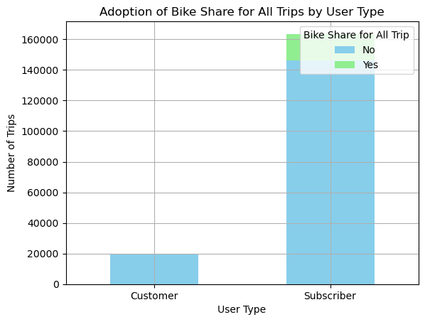

```python
# Plot the adoption of bike share for all trips by user type
plt.figure(figsize=(10, 6))
usage_by_user_type_share.plot(kind='bar', stacked=True, color=['skyblue', 'lightgreen'])
plt.title('Adoption of Bike Share for All Trips by User Type')
plt.xlabel('User Type')
plt.ylabel('Number of Trips')
plt.xticks(rotation=0)
plt.legend(title='Bike Share for All Trip', loc='upper right')
plt.grid(True)
plt.show()
```

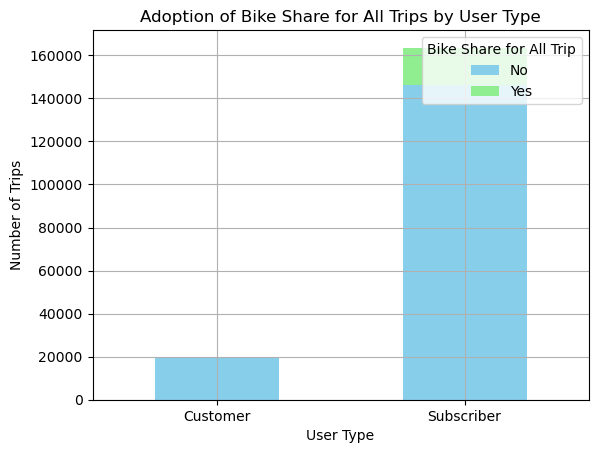

```python
# Plot the adoption of bike share for all trips by user type
plt.figure(figsize=(10, 6))
usage_by_user_type_share.plot(kind='bar', stacked=True, color=['skyblue', 'lightgreen'])
plt.title('Adoption of Bike Share for All Trips by User Type')
plt.xlabel('User Type')
plt.ylabel('Number of Trips')
plt.xticks(rotation=0)
plt.legend(title='Bike Share for All Trip', loc='upper right')
plt.grid(True)
plt.show()
```

```python
# Group the data by gender and bike share for all trips, and calculate the total number of trips for each combination
usage_by_gender_share = Bike.groupby(['member_gender', 'bike_share_for_all_trip']).size().unstack(fill_value=0)
```

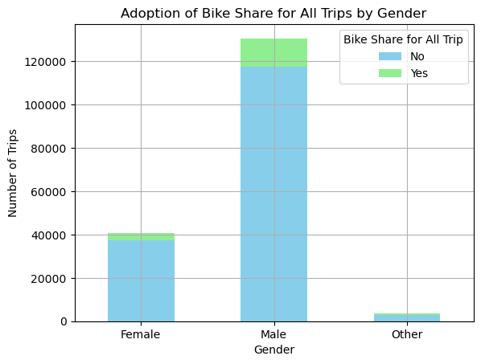

```python
# Plot the adoption of bike share for all trips by gender
plt.figure(figsize=(10, 6))
usage_by_gender_share.plot(kind='bar', stacked=True, color=['skyblue', 'lightgreen'])
plt.title('Adoption of Bike Share for All Trips by Gender')
plt.xlabel('Gender')
plt.ylabel('Number of Trips')
plt.xticks(rotation=0)
plt.legend(title='Bike Share for All Trip', loc='upper right')
plt.grid(True)
plt.show()
```

# TIME SERIES ANALYSIS

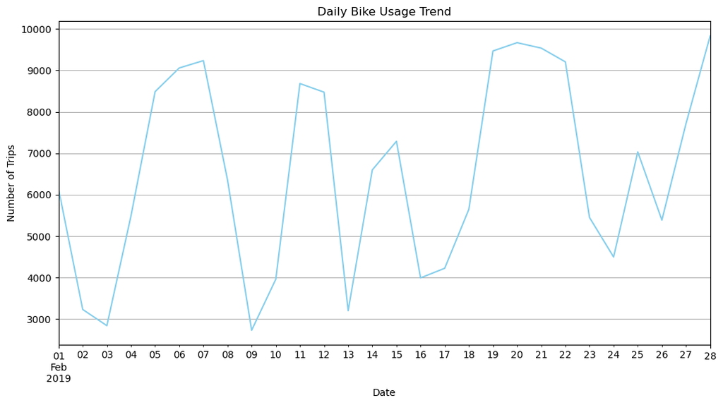

```python
import matplotlib.pyplot as plt

# Convert start_time to datetime and set it as the index
Bike['start_time'] = pd.to_datetime(Bike['start_time'])
Bike.set_index('start_time', inplace=True)

# Resample the data to daily frequency and calculate the number of trips for each day
daily_usage = Bike.resample('D').size()

# Plot the daily bike usage trend
plt.figure(figsize=(12, 6))
daily_usage.plot(color='skyblue')
plt.title('Daily Bike Usage Trend')
plt.xlabel('Date')
plt.ylabel('Number of Trips')
plt.grid(True)
plt.show()
```

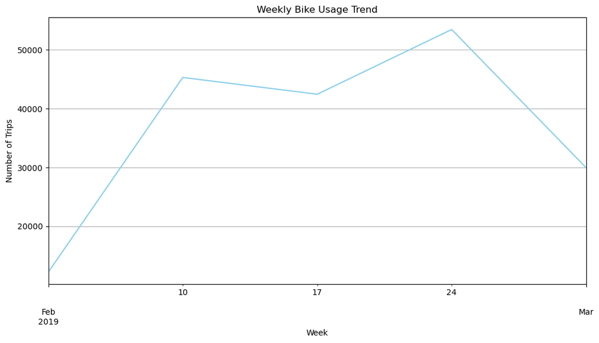

```python
# Resample the data to weekly frequency and calculate the number of trips for each week
weekly_usage = Bike.resample('W').size()

# Plot the weekly bike usage trend
plt.figure(figsize=(12, 6))
weekly_usage.plot(color='skyblue')
plt.title('Weekly Bike Usage Trend')
plt.xlabel('Week')
plt.ylabel('Number of Trips')
plt.grid(True)
plt.show()
```

# Analysis

## Is there a correlation between user age and trip duration?

```python
# Remove rows with missing values in 'member_birth_year' or 'duration_sec'
Bike_cleaned = Bike.dropna(subset=['member_birth_year', 'duration_sec']).copy()  # Make a copy to avoid modifying the original DataFrame
```

```python
# Calculate user age from 'member_birth_year' (assuming current year is 2024)
current_year = 2024
Bike_cleaned['user_age'] = current_year - Bike_cleaned['member_birth_year']
```

```python
# Calculate the correlation coefficient between user age and trip duration
correlation_coefficient = np.corrcoef(Bike_cleaned['user_age'], Bike_cleaned['duration_sec'])[0, 1]

print('Correlation Coefficient between User Age and Trip Duration:', correlation_coefficient)
```

```
Correlation Coefficient between User Age and Trip Duration: 0.006026742656500281
```

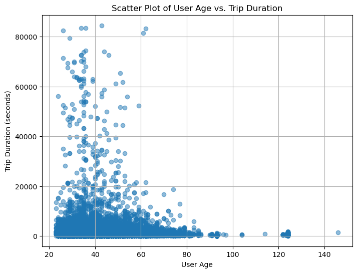

```python
# Plot a scatter plot to visualize the relationship
plt.figure(figsize=(8, 6))
plt.scatter(Bike_cleaned['user_age'], Bike_cleaned['duration_sec'], alpha=0.5)
plt.title('Scatter Plot of User Age vs. Trip Duration')
plt.xlabel('User Age')
plt.ylabel('Trip Duration (seconds)')
plt.grid(True)
plt.show()
```

## How does the usage of bike share for all trips vary between different user types and genders

```python
# Calculate the percentage of users who share bikes for all trips by user type
bike_share_by_user_type = Bike.groupby('user_type')['bike_share_for_all_trip'].value_counts(normalize=True) * 100
```

```python
# Calculate the percentage of users who share bikes for all trips by gender
bike_share_by_gender = Bike.groupby('member_gender')['bike_share_for_all_trip'].value_counts(normalize=True) * 100
```

```python
print('Percentage of Users who Share Bikes for All Trips by User Type:')
print(bike_share_by_user_type)
```

```
Percentage of Users who Share Bikes for All Trips by User Type:
user_type   bike_share_for_all_trip
Customer    No                         100.000000
Subscriber  No                          89.385731
            Yes                         10.614269
Name: proportion, dtype: float64
```

```python
print('\nPercentage of Users who Share Bikes for All Trips by Gender:')
print(bike_share_by_gender)
```

```
Percentage of Users who Share Bikes for All Trips by Gender:
member_gender  bike_share_for_all_trip
Female         No                         91.185976
               Yes                         8.814024
Male           No                         89.964868
               Yes                        10.035132
Other          No                         82.256298
               Yes                        17.743702
Name: proportion, dtype: float64
```